# The optimal we found is not the best we want

Statistics

Optimisation

Published

August 31, 2019

# Data Visualization

The yield data is from the paper Chen, O’Leary, and Evans (2019). The data is collected from two sites: CNT and NVT. We just focus on the site NVT.

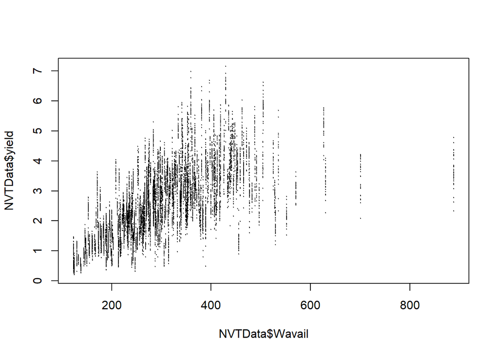

```r
NVTData <- read.table("NVTData.txt",header = TRUE)
plot(NVTData$Wavail,NVTData$yield,cex=0.1)
```

```r
datOR    <- NVTData[order(NVTData$Wavail),]
knotsNum <- length(table(datOR$Wavail)) # unique knots
```

The explanatory variables of NVT data comprises lat, longi, year, soils, Wavail, yield, where there are 362 unique *water of available* values.

# Model Fitting by `gam()`

**gam** refers to the generalized additive models with integrated smoothness estimation (Wood 2006). The functions `gam()` is in the package `mgcv`, which is developed by Wood and Wood (2015).

```r
fitgam.tp1 <- gam(yield ~ s(Wavail, bs = "tp"),data=datOR)
```

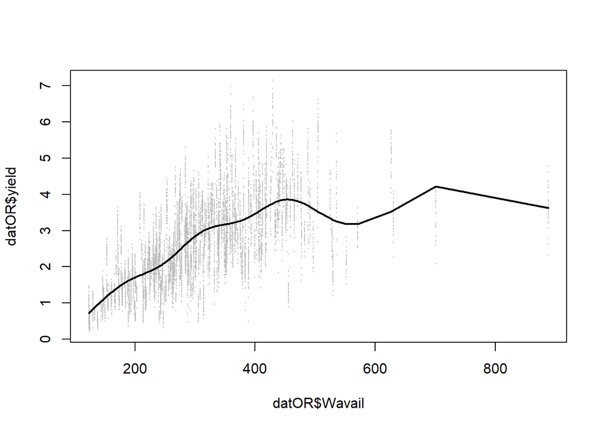

```r
plot(datOR$Wavail,datOR$yield,cex=0.1,col="gray")
points(datOR$Wavail,fitgam.tp1$fitted.values,type="l",lwd=2)
```

In the above model, the basis functions is `tp`, which refers to *thin plate regression spline*. In the following models, `cr` is for *cubic regression spline* and `gp` is for *Gaussian process models with a variety of simple correlation functions*.

```r
fitgam.tp2 <- gam(yield ~ s(Wavail,k=3, bs = "tp"), data = datOR)
fitgam.tp3 <- gam(yield ~ s(Wavail,k=10, bs = "tp"),data = datOR)
fitgam.tp4 <- gam(yield ~ s(Wavail,k=50, bs = "tp"),data = datOR)
fitgam.tp5 <- gam(yield ~ s(Wavail,k=100, bs = "tp"),data = datOR)
```

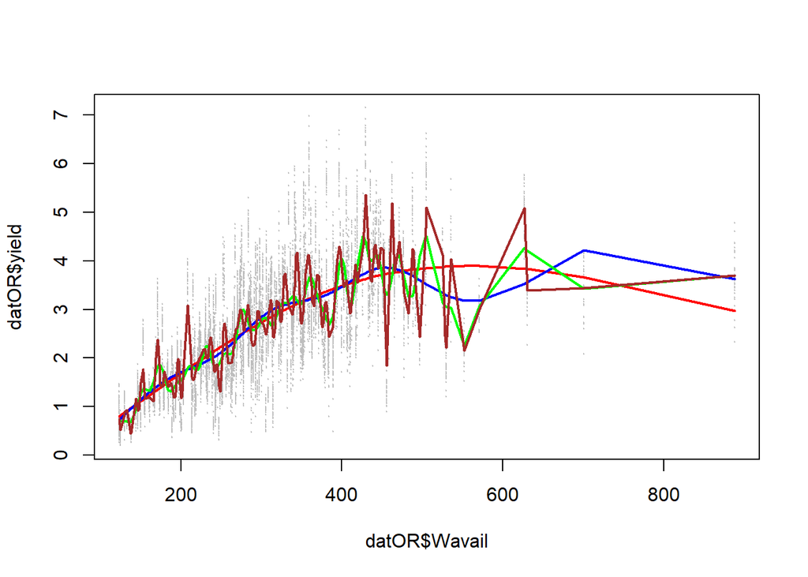

```r
plot(datOR$Wavail,datOR$yield,cex=0.1,col="gray")
points(datOR$Wavail,fitgam.tp2$fitted.values,type="l",col="red",lwd=2)
points(datOR$Wavail,fitgam.tp3$fitted.values,type="l",col="blue",lwd=2)
points(datOR$Wavail,fitgam.tp4$fitted.values,type="l",col="green",lwd=2)
points(datOR$Wavail,fitgam.tp5$fitted.values,type="l",col="brown",lwd=2)
```

```r
AIC(fitgam.tp2,fitgam.tp3,fitgam.tp4,fitgam.tp5)
```

```
##                    df      AIC
## fitgam.tp2   3.998908 30748.05
## fitgam.tp3  10.933138 30492.71
## fitgam.tp4  50.120859 29182.53
## fitgam.tp5 100.266214 26895.97
```

```r
BIC(fitgam.tp2,fitgam.tp3,fitgam.tp4,fitgam.tp5)
```

```
##                    df      BIC
## fitgam.tp2   3.998908 30777.73
## fitgam.tp3  10.933138 30573.87
## fitgam.tp4  50.120859 29554.61
## fitgam.tp5 100.266214 27640.31
```

### A different basis functions `cr`.

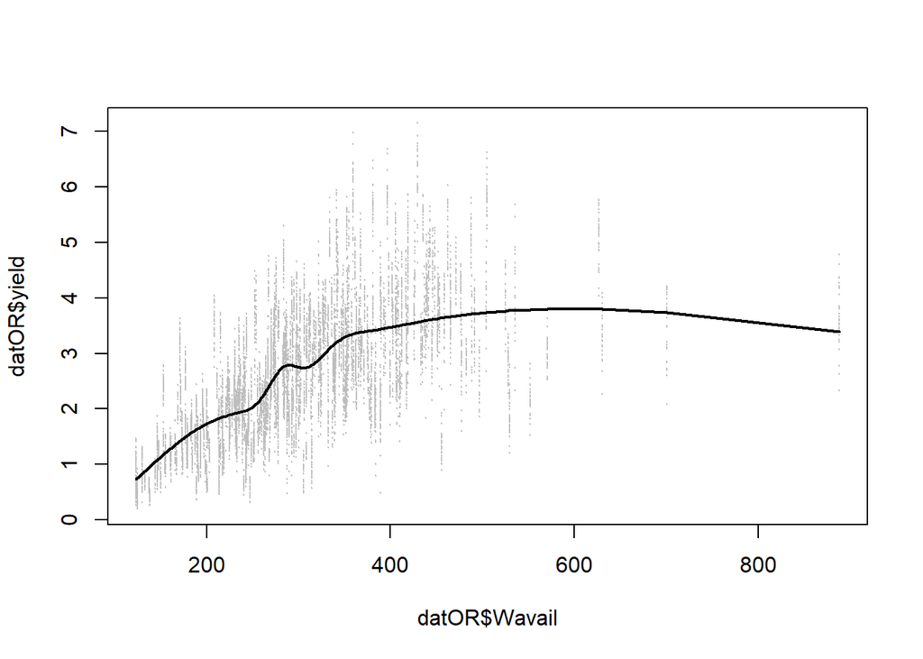

```r
fitgam.cr1 <- gam(yield ~ s(Wavail, bs = "cr"),data=datOR)
plot(datOR$Wavail,datOR$yield,cex=0.1,col="gray")
points(datOR$Wavail,fitgam.cr1$fitted.values,type="l",lwd=2)
```

```r
fitgam.cr2 <- gam(yield ~ s(Wavail,k=3, bs = "cr"), data = datOR)
fitgam.cr3 <- gam(yield ~ s(Wavail,k=10, bs = "cr"),data = datOR)
fitgam.cr4 <- gam(yield ~ s(Wavail,k=50, bs = "cr"),data = datOR)
fitgam.cr5 <- gam(yield ~ s(Wavail,k=100, bs = "cr"),data = datOR)
```

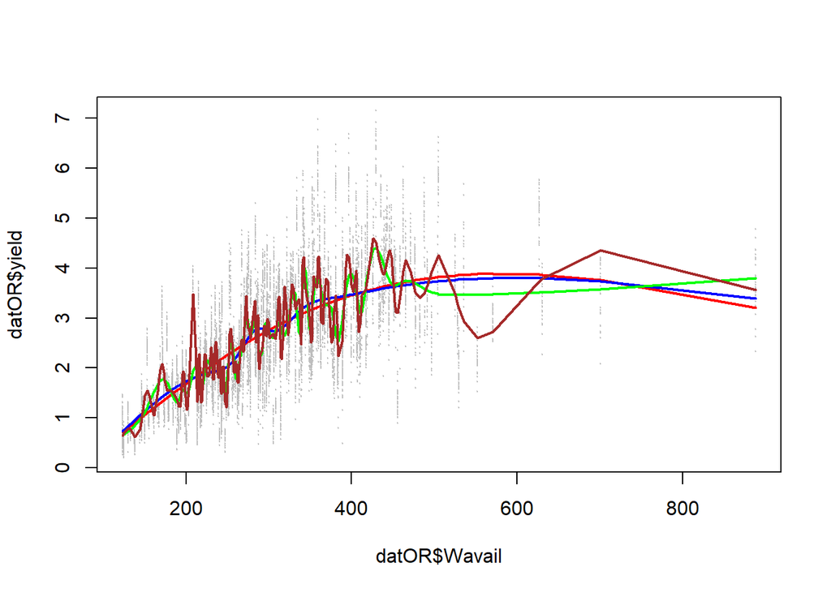

```r
plot(datOR$Wavail,datOR$yield,cex=0.1,col="gray")
points(datOR$Wavail,fitgam.cr2$fitted.values,type="l",col="red",lwd=2)
points(datOR$Wavail,fitgam.cr3$fitted.values,type="l",col="blue",lwd=2)
points(datOR$Wavail,fitgam.cr4$fitted.values,type="l",col="green",lwd=2)
points(datOR$Wavail,fitgam.cr5$fitted.values,type="l",col="brown",lwd=2)
```

```r
AIC(fitgam.cr2,fitgam.cr3,fitgam.cr4,fitgam.cr5)
```

```
##                    df      AIC
## fitgam.cr2   3.999819 30755.26
## fitgam.cr3  10.967775 30579.91
## fitgam.cr4  50.613471 29010.34
## fitgam.cr5 100.517310 27075.68
```

```r
BIC(fitgam.cr2,fitgam.cr3,fitgam.cr4,fitgam.cr5)
```

```
##                    df      BIC
## fitgam.cr2   3.999819 30784.96
## fitgam.cr3  10.967775 30661.33
## fitgam.cr4  50.613471 29386.08
## fitgam.cr5 100.517310 27821.88
```

### A different basis functions `gp`.

```r
fitgam.gp2 <- gam(yield ~ s(Wavail,k=3, bs = "gp"), data = datOR)
fitgam.gp3 <- gam(yield ~ s(Wavail,k=10, bs = "gp"),data = datOR)
fitgam.gp4 <- gam(yield ~ s(Wavail,k=50, bs = "gp"),data = datOR)
fitgam.gp5 <- gam(yield ~ s(Wavail,k=100, bs = "gp"),data = datOR)
```

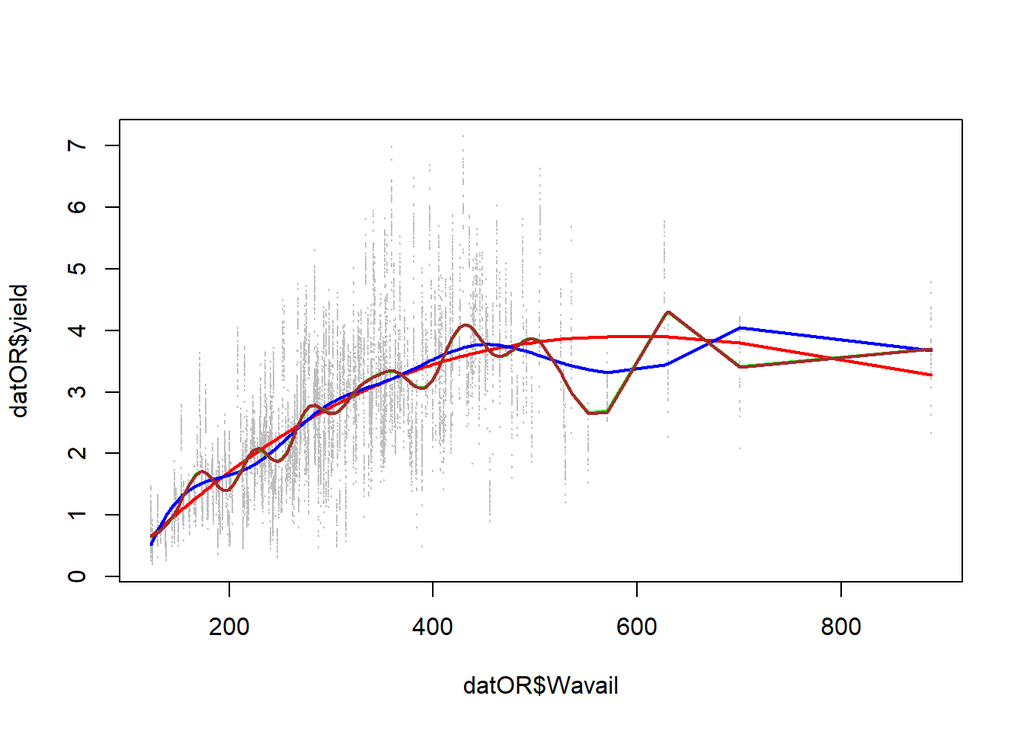

```r
plot(datOR$Wavail,datOR$yield,cex=0.1,col="gray")
points(datOR$Wavail,fitgam.gp2$fitted.values,type="l",col="red",lwd=2)
points(datOR$Wavail,fitgam.gp3$fitted.values,type="l",col="blue",lwd=2)
points(datOR$Wavail,fitgam.gp4$fitted.values,type="l",col="green",lwd=2)
points(datOR$Wavail,fitgam.gp5$fitted.values,type="l",col="brown",lwd=2)
```

```r
AIC(fitgam.gp2,fitgam.gp3,fitgam.gp4,fitgam.gp5)
```

```
##                   df      AIC
## fitgam.gp2  3.999795 30774.97
## fitgam.gp3 10.968502 30525.49
## fitgam.gp4 21.906114 29926.96
## fitgam.gp5 22.203024 29924.30
```

```r
BIC(fitgam.gp2,fitgam.gp3,fitgam.gp4,fitgam.gp5)
```

```
##                   df      BIC
## fitgam.gp2  3.999795 30804.67
## fitgam.gp3 10.968502 30606.92
## fitgam.gp4 21.906114 30089.58
## fitgam.gp5 22.203024 30089.13
```

### Comparison of different selection critera

```r
aics.tp <- numeric(knotsNum)
gcvs.tp <- numeric(knotsNum)
devs.tp <- numeric(knotsNum)
aics.gp <- numeric(knotsNum)
gcvs.gp <- numeric(knotsNum)
devs.gp <- numeric(knotsNum)
for(kts in 3:knotsNum){
  fitgam.tp.temp <- gam(yield ~ s(Wavail,k=kts, bs = "tp"),
                        data = datOR)
  aics.tp[kts] <- fitgam.tp.temp$aic
  gcvs.tp[kts] <- fitgam.tp.temp$gcv.ubre
  devs.tp[kts] <- fitgam.tp.temp$deviance
  fitgam.gp.temp <- gam(yield ~ s(Wavail,k=kts, bs = "gp"),                              data = datOR)
  aics.gp[kts] <- fitgam.gp.temp$aic
  gcvs.gp[kts] <- fitgam.gp.temp$gcv.ubre
  devs.gp[kts] <- fitgam.gp.temp$deviance
  cat(kts);
}
```

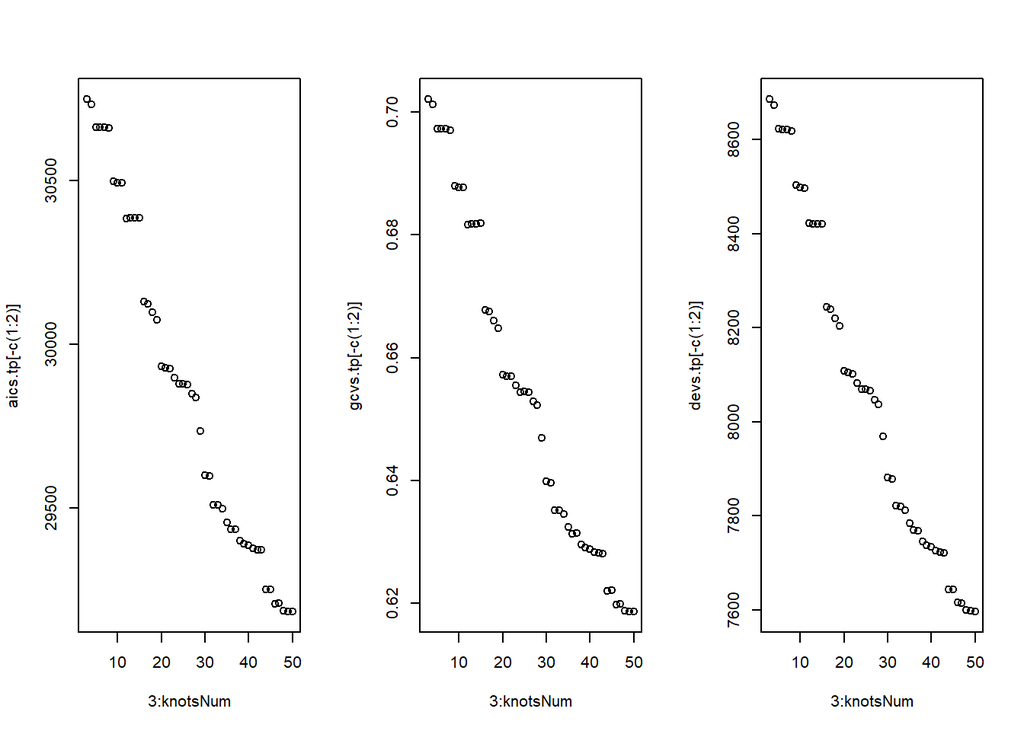

```r
knotsNum<- 50
par(mfrow=c(1,3))
plot(3:knotsNum,aics.tp[-c(1:2)])
plot(3:knotsNum,gcvs.tp[-c(1:2)])
plot(3:knotsNum,devs.tp[-c(1:2)])
```

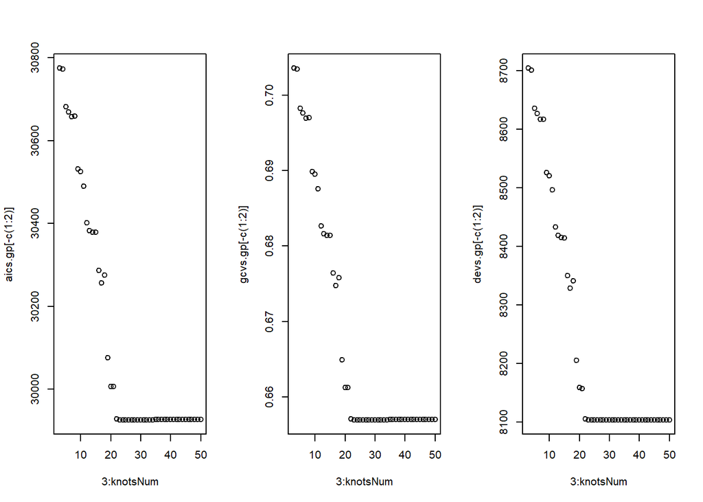

```r
par(mfrow=c(1,1))

par(mfrow=c(1,3))
plot(3:knotsNum,aics.gp[-c(1:2)])
plot(3:knotsNum,gcvs.gp[-c(1:2)])
plot(3:knotsNum,devs.gp[-c(1:2)])
```

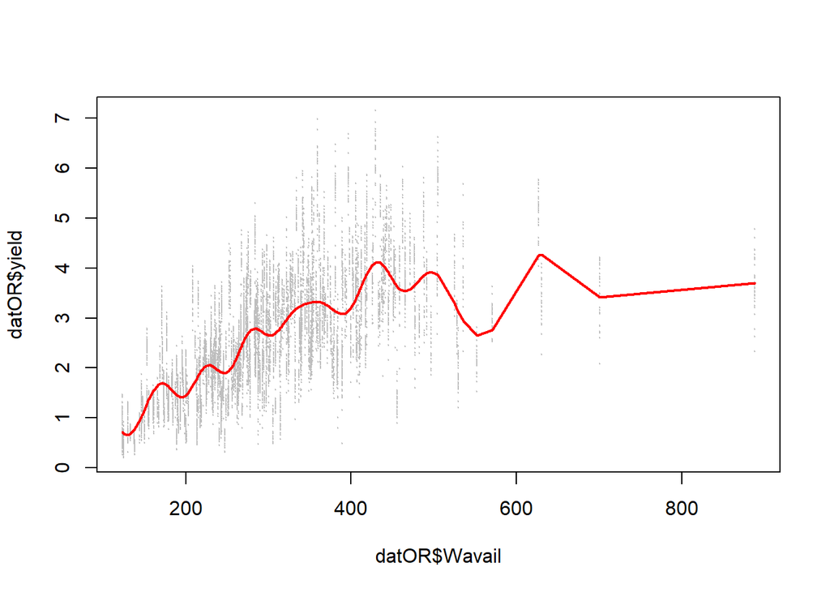

```r
par(mfrow=c(1,1))

fitgam.gp6 <- gam(yield ~ s(Wavail,k=22, bs = "gp"),data = datOR)
plot(datOR$Wavail,datOR$yield,cex=0.1,col="gray")
points(datOR$Wavail,fitgam.gp6$fitted.values,type="l",col="red",lwd=2)
```

However, the contradiction still exists

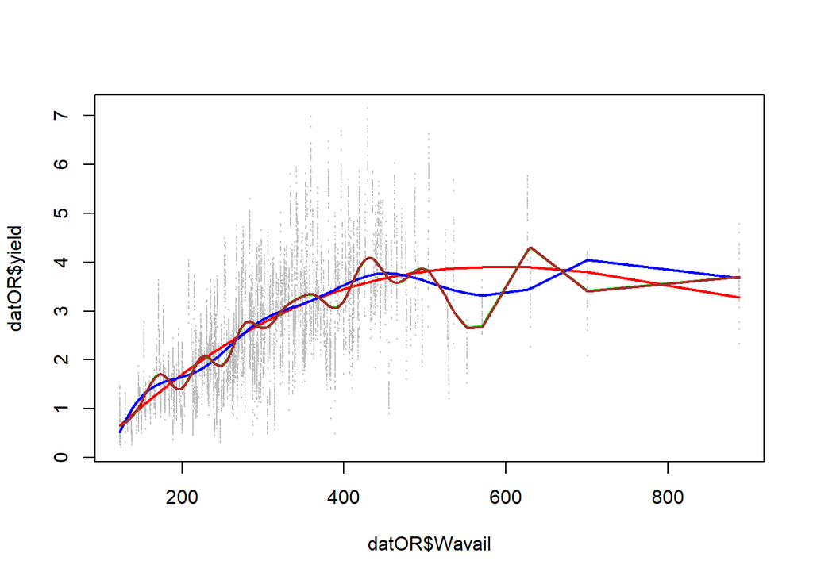

```r
plot(datOR$Wavail,datOR$yield,cex=0.1,col="gray")
points(datOR$Wavail,fitgam.gp2$fitted.values,type="l",col="red",lwd=2)
points(datOR$Wavail,fitgam.gp3$fitted.values,type="l",col="blue",lwd=2)
points(datOR$Wavail,fitgam.gp4$fitted.values,type="l",col="green",lwd=2)
points(datOR$Wavail,fitgam.gp5$fitted.values,type="l",col="brown",lwd=2)
```

# A possible solution: aggregative data

```r
datOR.agg <- aggregate(datOR[c("lat","longi","year","Wavail","yield")],list(datOR$Wavail),mean)
names(datOR.agg)[1] <- c("WavailAgg")
```

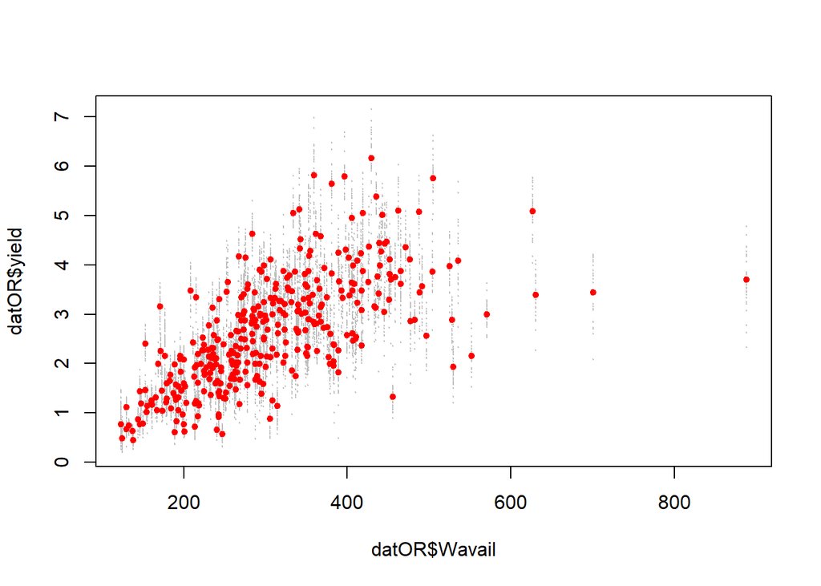

```r
plot(datOR$Wavail,datOR$yield,cex=0.1,pch=20,col="grey")
points(datOR.agg$WavailAgg,datOR.agg$yield,pch=20,col="red")
```

By taking the means for each unique *Wavail*, we have the aggregative data, which has 362 rows rather than 12377.

```r
aics.agg <- numeric(knotsNum)
gcvs.agg <- numeric(knotsNum)
devs.agg <- numeric(knotsNum)
for(kts in 3:knotsNum){
  fitgam.agg    <- gam(yield ~ s(Wavail,k=kts,bs = "gp"),
                       data=datOR.agg)
  aics.agg[kts] <- fitgam.agg$aic
  gcvs.agg[kts] <- fitgam.agg$gcv.ubre
  devs.agg[kts] <- fitgam.agg$deviance
  cat(kts);
}
```

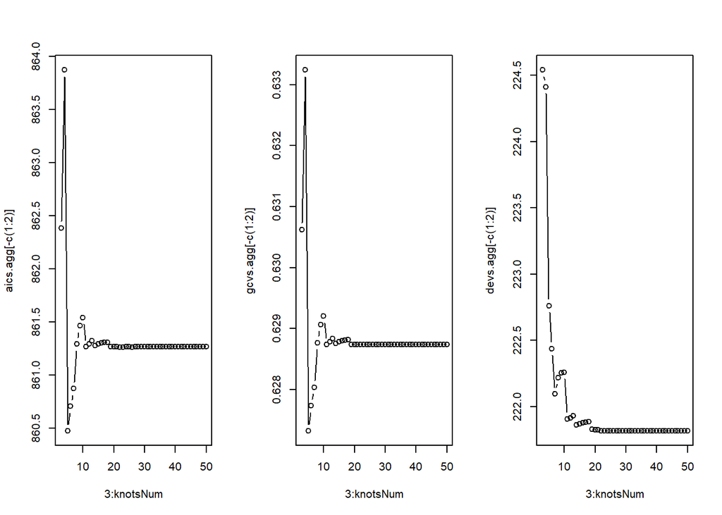

```r
par(mfrow=c(1,3))
plot(3:knotsNum,aics.agg[-c(1:2)],type="b")
plot(3:knotsNum,gcvs.agg[-c(1:2)],type="b")
plot(3:knotsNum,devs.agg[-c(1:2)],type="b")
```

```r
par(mfrow=c(1,1))
```

```r
fitgam.gp.agg1 <- gam(yield ~ s(Wavail,k=3, bs = "gp"), data=datOR.agg)
fitgam.gp.agg2 <- gam(yield ~ s(Wavail,k=5, bs = "gp"), data=datOR.agg)
fitgam.gp.agg3 <- gam(yield ~ s(Wavail,k=10,bs = "gp"), data=datOR.agg)
```

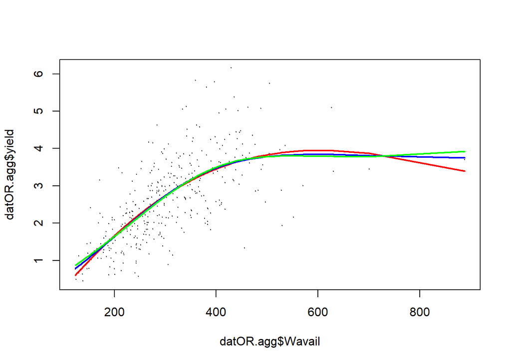

```r
plot(datOR.agg$Wavail,datOR.agg$yield,cex=0.1,pch=20)
points(datOR.agg$Wavail,fitgam.gp.agg1$fitted.values,type="l",col="red",lwd=2)
points(datOR.agg$Wavail,fitgam.gp.agg2$fitted.values,type = "l",col="blue",lwd=2)
points(datOR.agg$Wavail,fitgam.gp.agg3$fitted.values,type = "l",col="green",lwd=2)
```

# Another solution: taking a subset

By taking a subset of size $N$ from the origianl data set, we may reduce the variance.

```r
set.seed(2019)
s<- sort(sample(1:nrow(datOR),1000))
datOR.subset  <- datOR[s,]
knotsNum  <- 50
aics.subset <- numeric(knotsNum)
gcvs.subset <- numeric(knotsNum)
divs.subset <- numeric(knotsNum)
for(kts in 3:knotsNum){
  fitgam.subset    <- gam(yield ~ s(Wavail,k=kts, bs = "gp"),
                            data=datOR.subset)
  aics.subset[kts] <- fitgam.subset$aic
  gcvs.subset[kts] <- fitgam.subset$gcv.ubre
  divs.subset[kts] <- fitgam.subset$deviance
}
```

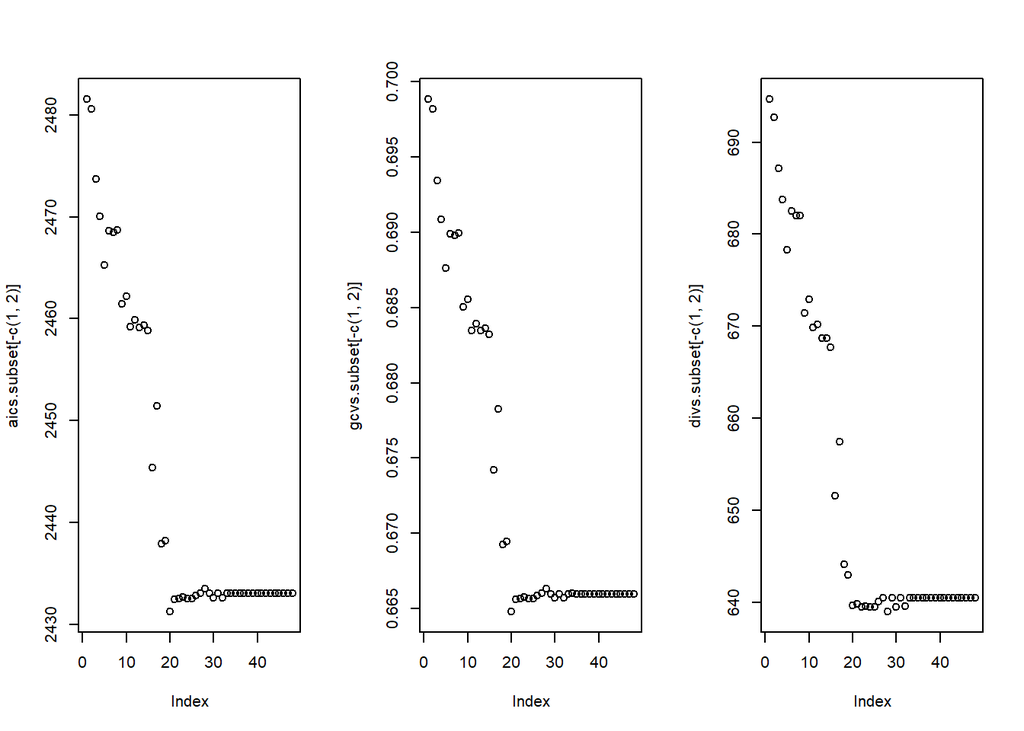

```r
par(mfrow=c(1,3))
plot(aics.subset[-c(1,2)])
plot(gcvs.subset[-c(1,2)])
plot(divs.subset[-c(1,2)])
```

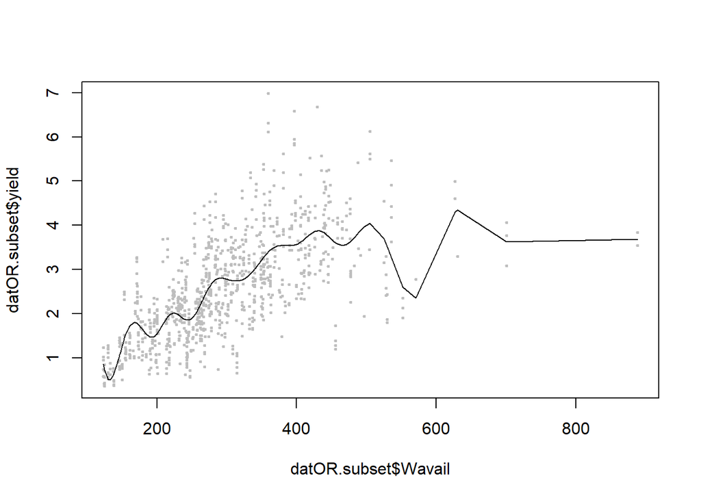

```r
par(mfrow=c(1,1))
fitgam.subset <- gam(yield ~ s(Wavail,k=20, bs = "gp"),
                        data=datOR.subset)
plot(datOR.subset$Wavail,datOR.subset$yield,cex=0.5,pch=20,col="grey")
points(datOR.subset$Wavail,fitgam.subset$fitted.values,type="l")
```

# A bootstrap and naive resampling

```r
datOR.sample <- NULL
wavs <- names(table(datOR$Wavail))
set.seed(2019)
for(k in wavs){
  tempdat<- datOR[which(datOR$Wavail == k),]
  s<- sort(sample(1:nrow(tempdat),1))
  datOR.sample<-rbind(datOR.sample,tempdat[s,])
}
fitgam.sample <- gam(yield  ~ s(Wavail,k=30,bs = "gp"),
                     data=datOR.sample)
```

Taking one sample from each unique Wavail, we have the subset, which contains 362 rows. It is similar to the *aggregative data* approach.

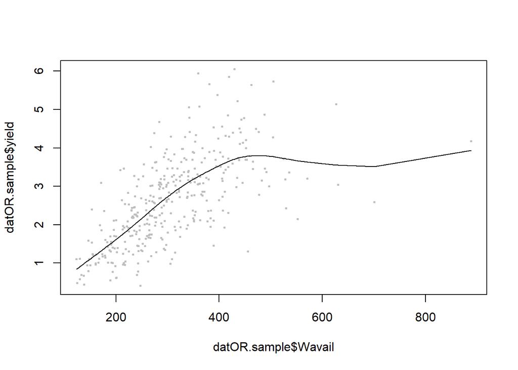

```r
plot(datOR.sample$Wavail,datOR.sample$yield,cex=0.5,pch=20,col="grey")
points(datOR.sample$Wavail,fitgam.sample$fitted.values,type = "l")
```

```r
fitgam.gp.sample1 <- gam(yield ~ s(Wavail,k=3,bs = "gp"), data=datOR.sample)
fitgam.gp.sample2 <- gam(yield ~ s(Wavail,k=10,bs = "gp"), data=datOR.sample)
fitgam.gp.sample3 <- gam(yield ~ s(Wavail,k=50,bs = "gp"), data=datOR.sample)
fitgam.gp.sample4 <- gam(yield ~ s(Wavail,k=100,bs = "gp"), data=datOR.sample)
```

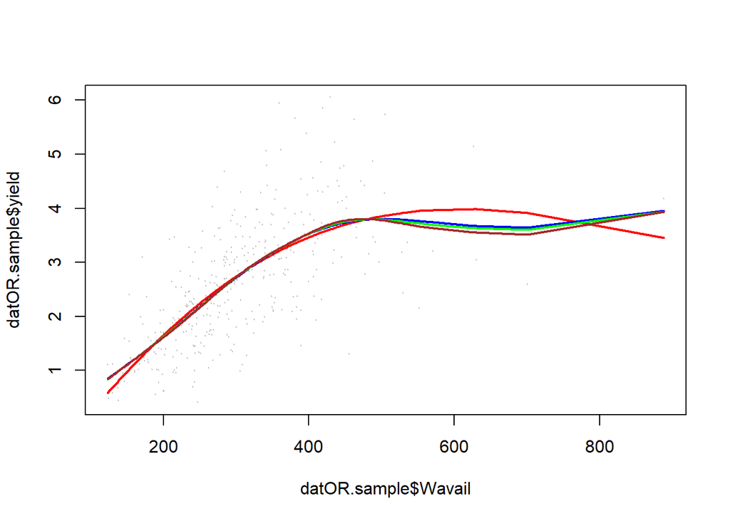

```r
plot(datOR.sample$Wavail,datOR.sample$yield,cex=0.1,pch=20,col="grey")
points(datOR.sample$Wavail,fitgam.gp.sample1$fitted.values,type = "l",col="red",lwd=2)
points(datOR.sample$Wavail,fitgam.gp.sample2$fitted.values,type = "l",col="blue",lwd=2)
points(datOR.sample$Wavail,fitgam.gp.sample3$fitted.values,type = "l",col="green",lwd=2)
points(datOR.sample$Wavail,fitgam.gp.sample4$fitted.values,type = "l",col="brown",lwd=2)
```

```r
AIC(fitgam.gp.sample1,fitgam.gp.sample2,fitgam.gp.sample3,fitgam.gp.sample4)
```

```
##                         df      AIC
## fitgam.gp.sample1 3.979491 886.6777
## fitgam.gp.sample2 5.735994 884.1414
## fitgam.gp.sample3 6.161752 883.8681
## fitgam.gp.sample4 6.720663 883.9109
```

```r
BIC(fitgam.gp.sample1,fitgam.gp.sample2,fitgam.gp.sample3,fitgam.gp.sample4)
```

```
##                         df      BIC
## fitgam.gp.sample1 3.979491 902.1644
## fitgam.gp.sample2 5.735994 906.4638
## fitgam.gp.sample3 6.161752 907.8474
## fitgam.gp.sample4 6.720663 910.0654
```

## Repeat the bootstrap sampling (naive resampling) for 30 times.

```r
N <- 30
boost.max1 <- matrix(0,N,362)
boost.max2 <- matrix(0,N,362)
boost.max3 <- matrix(0,N,362)
boost.max4 <- matrix(0,N,362)
rowNms <- matrix(0,N,362)
set.seed(2019)
for(i in 1:N){
  datOR.boost <- NULL
  for(k in wavs){
    tempdat<- datOR[which(datOR$Wavail == k),]
    s<- sort(sample(1:nrow(tempdat),1))
    datOR.boost<-rbind(datOR.boost,tempdat[s,])
  }
  fitgam.gp.boost1 <- gam(yield ~ s(Wavail,k=3,bs="gp"),  data=datOR.boost)
  fitgam.gp.boost2 <- gam(yield ~ s(Wavail,k=10,bs="gp"), data=datOR.boost)
  fitgam.gp.boost3 <- gam(yield ~ s(Wavail,k=50,bs="gp"), data=datOR.boost)
  fitgam.gp.boost4 <- gam(yield ~ s(Wavail,k=100,bs="gp"),data=datOR.boost)
  boost.max1[i,] <- fitgam.gp.boost1$fitted.values
  boost.max2[i,] <- fitgam.gp.boost2$fitted.values
  boost.max3[i,] <- fitgam.gp.boost3$fitted.values
  boost.max4[i,] <- fitgam.gp.boost4$fitted.values
  rowNms[i,]     <- row.names(datOR.boost)
}
```

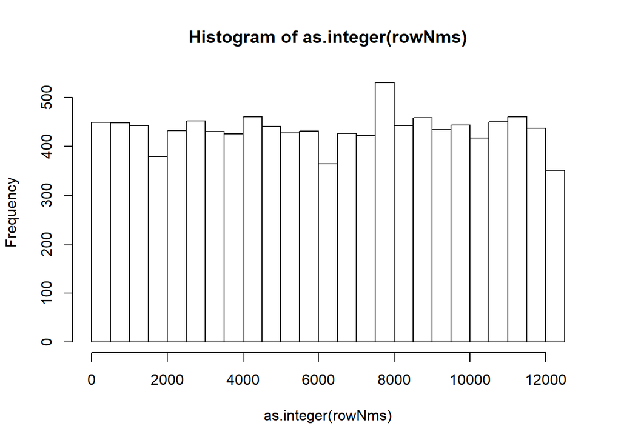

```r
hist(as.integer(rowNms),30)
```

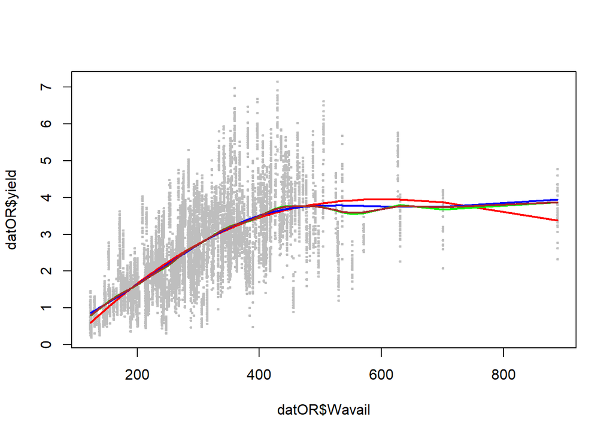

```r
plot(datOR$Wavail,datOR$yield,cex=0.5,pch=20,col="grey")
points(wavs,apply(boost.max1,2,mean),type="l",col="red",lwd=2)
points(wavs,apply(boost.max2,2,mean),type="l",col="blue",lwd=2)
points(wavs,apply(boost.max3,2,mean),type="l",col="green",lwd=2)
points(wavs,apply(boost.max4,2,mean),type="l",col="brown",lwd=2)
```

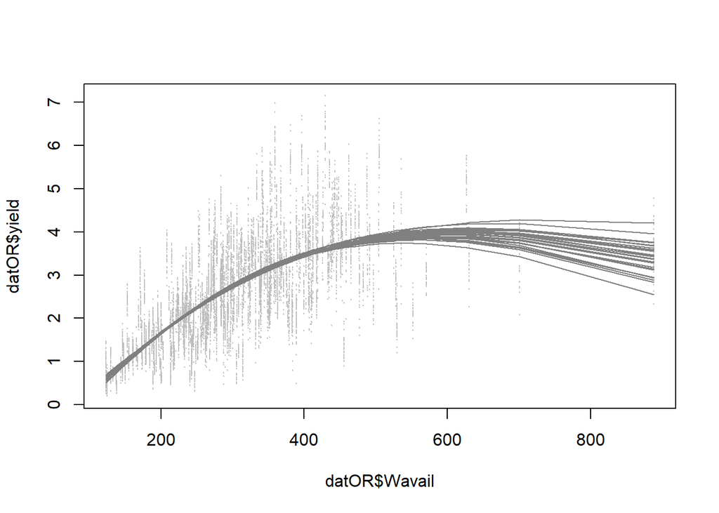

```r
plot(datOR$Wavail,datOR$yield,cex=0.1,pch=20,col="grey")
for(k in 1:N) points(wavs,boost.max1[k,],col=grey(0.5),type="l")
```

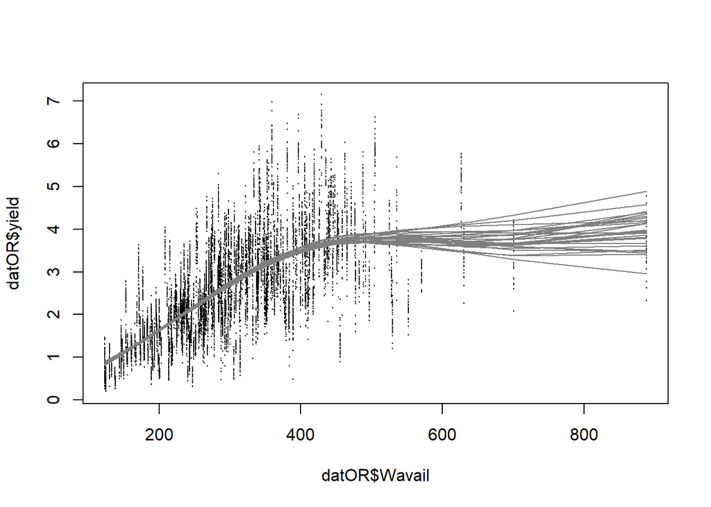

```r
plot(datOR$Wavail,datOR$yield,cex=0.1)
for(k in 1:N) points(wavs,boost.max2[k,],col=grey(0.5),type="l")
```

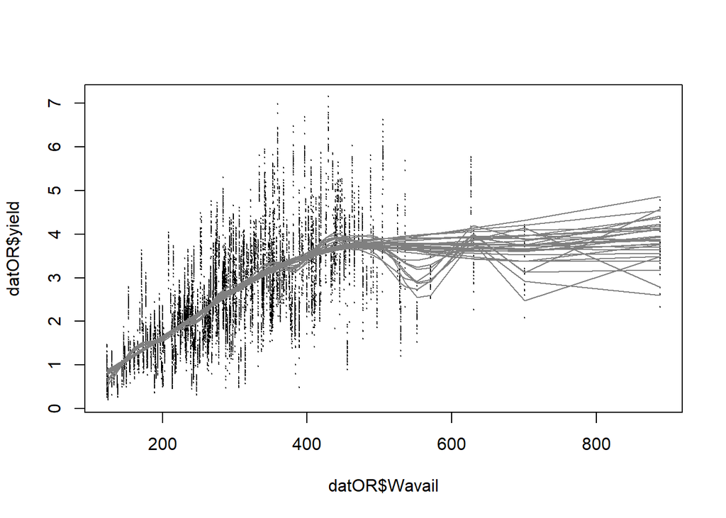

```r
plot(datOR$Wavail,datOR$yield,cex=0.1)
for(k in 1:N) points(wavs,boost.max3[k,],col=grey(0.5),type="l")
```

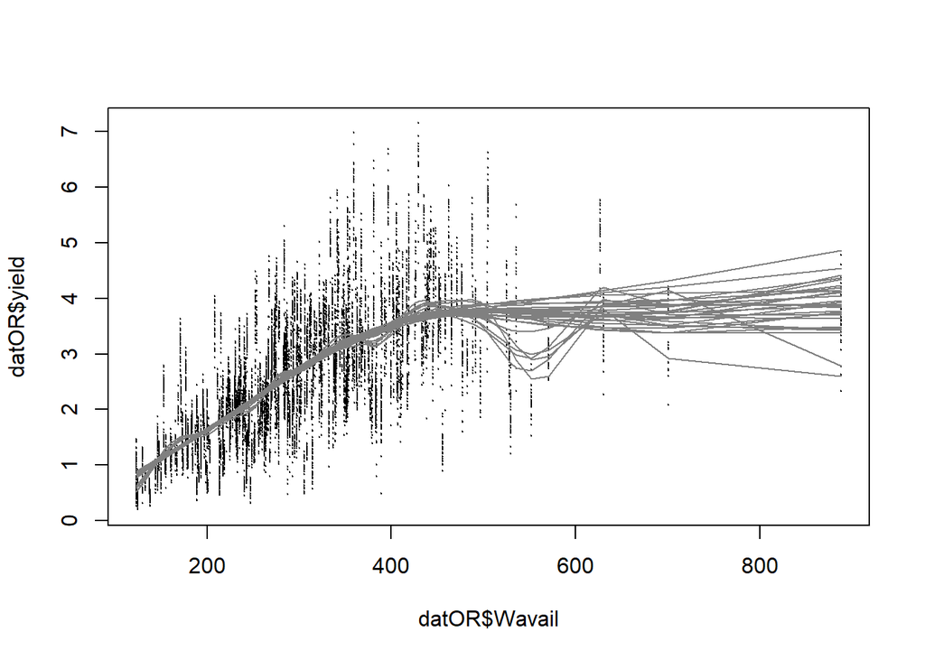

```r
plot(datOR$Wavail,datOR$yield,cex=0.1)
for(k in 1:N) points(wavs,boost.max4[k,],col=grey(0.5),type="l")
```

Comparison of $AIC$s, $BIC$s and deviances.

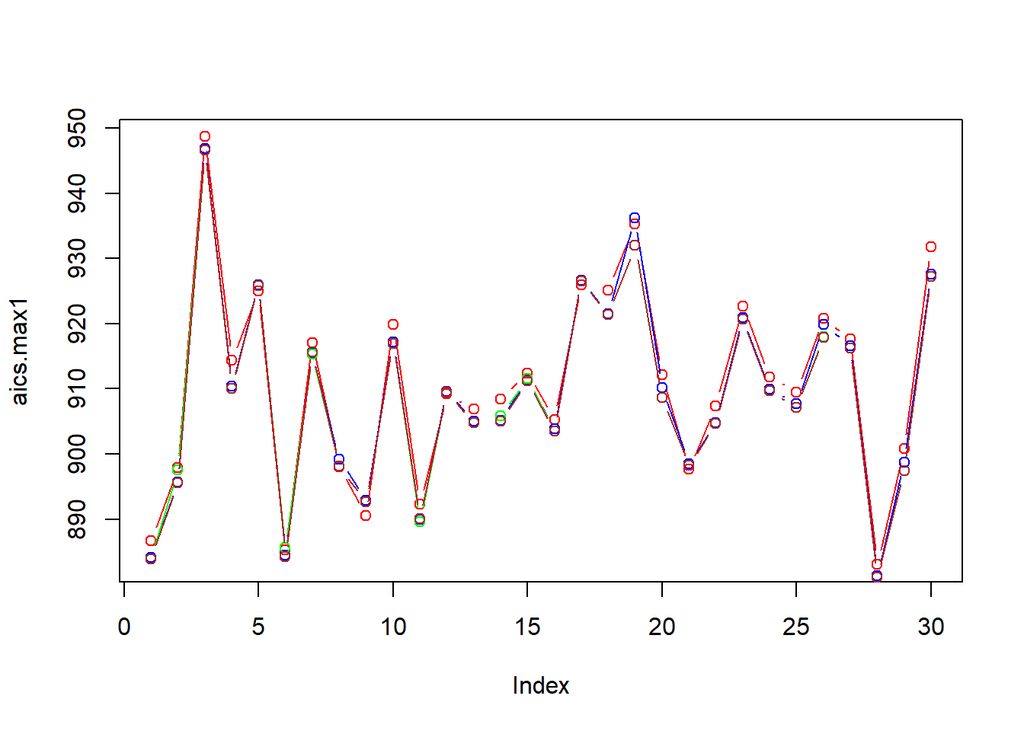

```r
plot(aics.max1,type="b",col="red")
points(aics.max2,type="b",col="blue")
points(aics.max3,type="b",col="green")
points(aics.max4,type="b",col="brown")
```

```r
mean(aics.max1);mean(aics.max2);mean(aics.max3);mean(aics.max4)
```

```
## [1] 910.6492
```

```
## [1] 909.2509
```

```
## [1] 908.8717
```

```
## [1] 908.7469
```

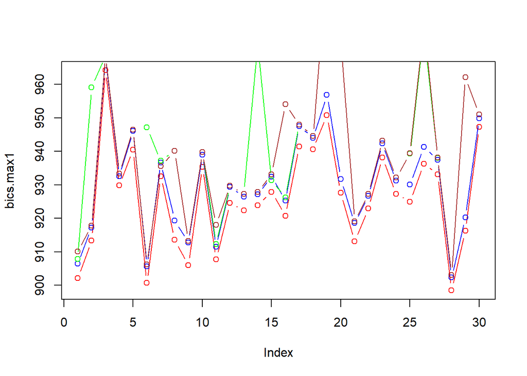

```r
plot(bics.max1,type="b",col="red")
points(bics.max2,type="b",col="blue")
points(bics.max3,type="b",col="green")
points(bics.max4,type="b",col="brown")
```

```r
mean(bics.max1);mean(bics.max2);mean(bics.max3);mean(bics.max4)
```

```
## [1] 926.1302
```

```
## [1] 930.5354
```

```
## [1] 941.4827
```

```
## [1] 938.555
```

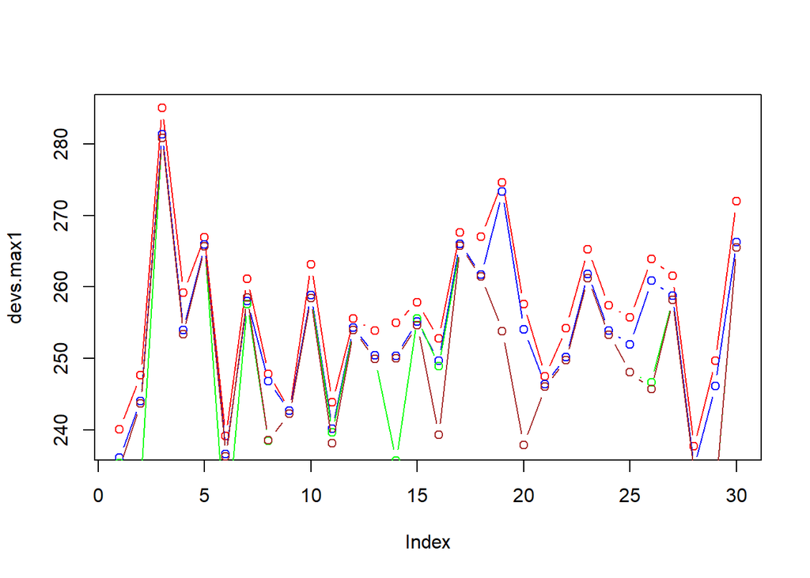

```r
plot(devs.max1,type="b",col="red")
points(devs.max2,type="b",col="blue")
points(devs.max3,type="b",col="green")
points(devs.max4,type="b",col="brown")
```

```r
mean(devs.max1);mean(devs.max2);mean(devs.max3);mean(devs.max4)
```

```
## [1] 256.7962
```

```
## [1] 253.7053
```

```
## [1] 249.4922
```

```
## [1] 250.3439
```

This approach is NOT robust.

# A cutting off CV OR stratified CV

In the stratified cross-validation (SCV), the values $\mathbf{y}_i$, which denote all measured time points corresponding to an individual $i$, are taken from the data set for further testing. The rest data $\mathbf{y}^{-i}$, is used for training the model.

The *cutting off* CV is taking a bunch of consecutive individuals $i,\ldots,i+k$ from the data set for testing.

For example

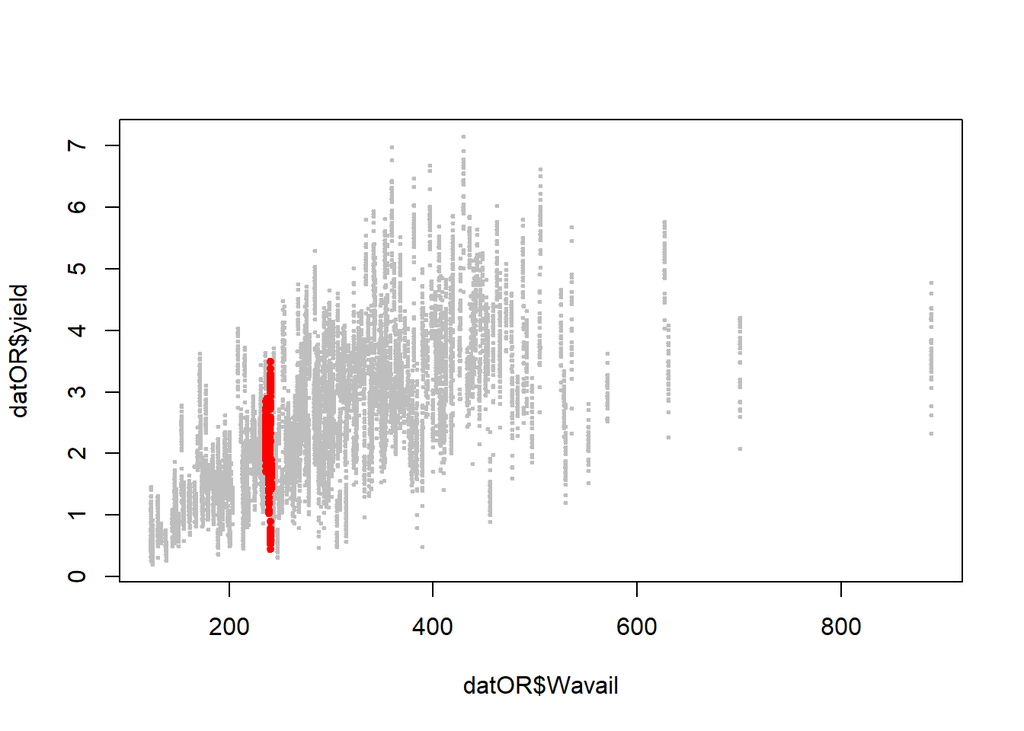

```r
tempTests <- subset(datOR,datOR$Wavail %in% wavs[91:100])
plot(datOR$Wavail,datOR$yield,pch=20,cex=0.5,col="grey")
points(tempTests$Wavail,tempTests$yield,pch=20,col="red")
```

```r
wavs <- names(table(datOR$Wavail))
knotsNum <- length(wavs)
cv.train <- matrix(0,knotsNum,knotsNum)
cv.tests <- matrix(0,knotsNum,knotsNum)

kfo <- 5
sq1 <- seq(3,30,by=1)
sq2 <- 2:(knotsNum-kfo)

for(nkts in sq1){
  for(st in sq2){
    s         <- st:(st+kfo-1)
    tempTrain <- subset(datOR,!(datOR$Wavail %in% wavs[s]))
    tempTests <- subset(datOR,datOR$Wavail %in% wavs[s])
    fitgam.gp.cv <- gam(yield ~ s(Wavail,k=nkts), data=tempTrain)
    cv.train[nkts,st] <- RMSE(fitgam.gp.cv$fitted.values,tempTrain$yield)
    preTest <- predict(fitgam.gp.cv,data.frame(Wavail = tempTests$Wavail))
    cv.tests[nkts,st] <- RMSE(preTest,tempTests$yield)
  }
  cat(nkts);
}
```

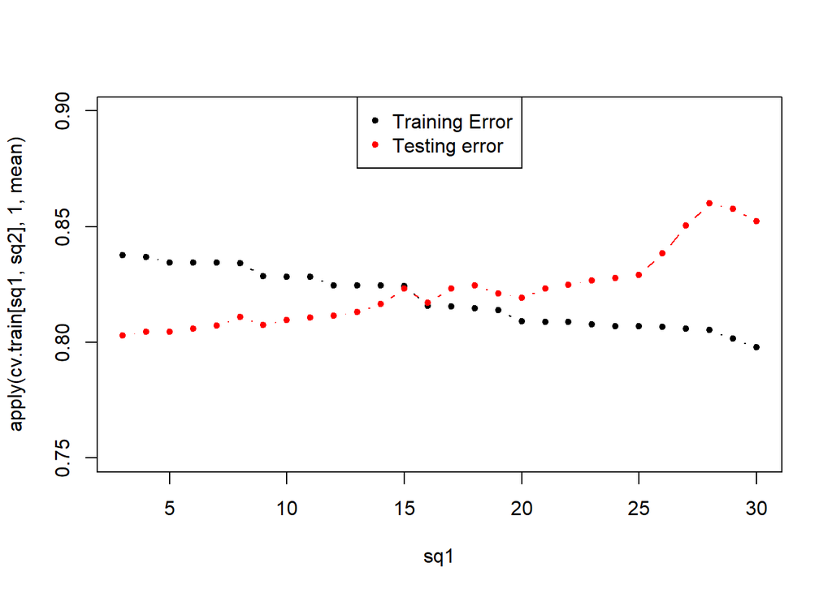

```r
plot(sq1,apply(cv.train[sq1,sq2],1,mean),ylim=c(0.75,0.9),pch=20,type="b")
points(sq1,apply(cv.tests[sq1,sq2],1,mean),col="red",pch=20,type="b")
legend("top", legend=c("Training Error", "Testing error"), col=c("black", "red"),pch=c(20,20))
```

The training error and testing error are balanced at the 15.

# Constrained Generalized Additive Model Fitting

According to the value of the vector itself and its shape, numknots, knots and space attributes, the cone edges will be made by C-spline basis functions, where C-spline refers to convex regression spline (Meyer 2008, @meyer2013semi).

```r
library(cgam)
fitcgam1 <- cgam(yield ~ s.incr.conc(Wavail,numknots=3),  data=datOR)
fitcgam2 <- cgam(yield ~ s.incr.conc(Wavail,numknots=10), data=datOR)
fitcgam3 <- cgam(yield ~ s.incr.conc(Wavail,numknots=50), data=datOR)
fitcgam4 <- cgam(yield ~ s.incr.conc(Wavail,numknots=100),data=datOR)
```

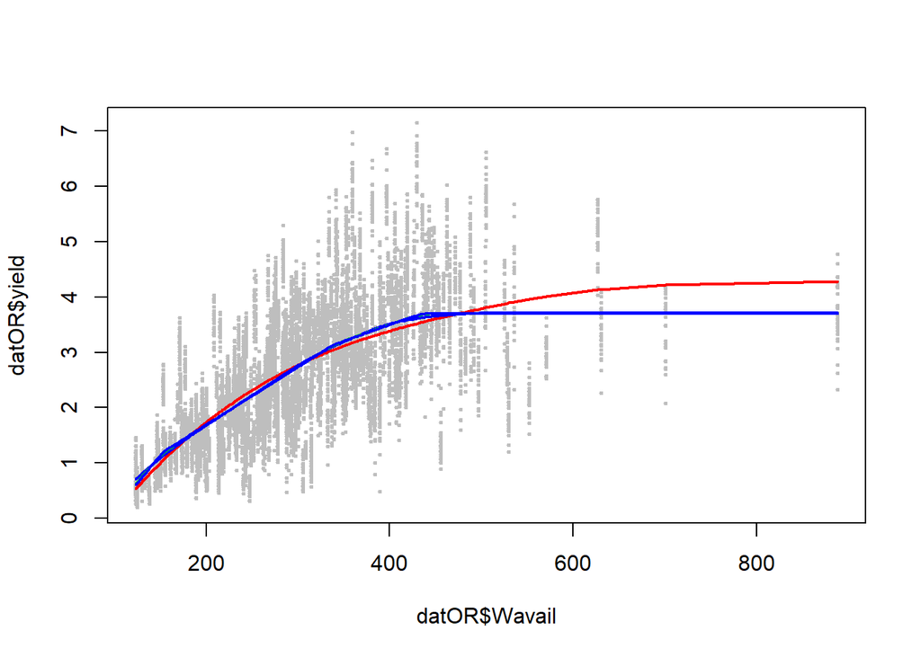

```r
plot(datOR$Wavail,datOR$yield,cex=0.5,pch=20,col="grey")
points(datOR$Wavail,fitcgam1$muhat,type = "l",lwd=2,col="red")
points(datOR$Wavail,fitcgam2$muhat,type = "l",lwd=2,col="blue")
points(datOR$Wavail,fitcgam3$muhat,type = "l",lwd=2,col="green")
points(datOR$Wavail,fitcgam4$muhat,type = "l",lwd=2,col="blue")
```

```r
fitcgam1$deviance
```

```
## [1] 8815.735
```

```r
fitcgam2$deviance
```

```
## [1] 8630.178
```

```r
fitcgam3$deviance
```

```
## [1] 8584.179
```

```r
fitcgam4$deviance
```

```
## [1] 8579.372
```

A drawback of `cgam` is that it doesn’t work for the interaction of two variables, where `gam` does.

```r
fitcgam1.s <- cgam(yield ~ s.incr.conc(Wavail,numknots=3) +
                   s(lat,longi, numknots = 6), data=datOR)
# system crash
```

# Comparison of `gam()` and `cgam()` on deviance

```r
kts     <- seq(3,40)
gamDev  <- numeric(102)
cgamDev <- numeric(102)
for(k in kts){
  gamfit    <- gam(yield ~ s(Wavail,k=k,bs="gp"), data=datOR)
  gamDev[k] <- gamfit$deviance
  cat(k);
}
for(k in kts){
  cgamfit   <- cgam(yield ~ s.incr.conc(Wavail,numknots=k), data=datOR)
  cgamDev[k]<- cgamfit$deviance
  cat(k);
}
```

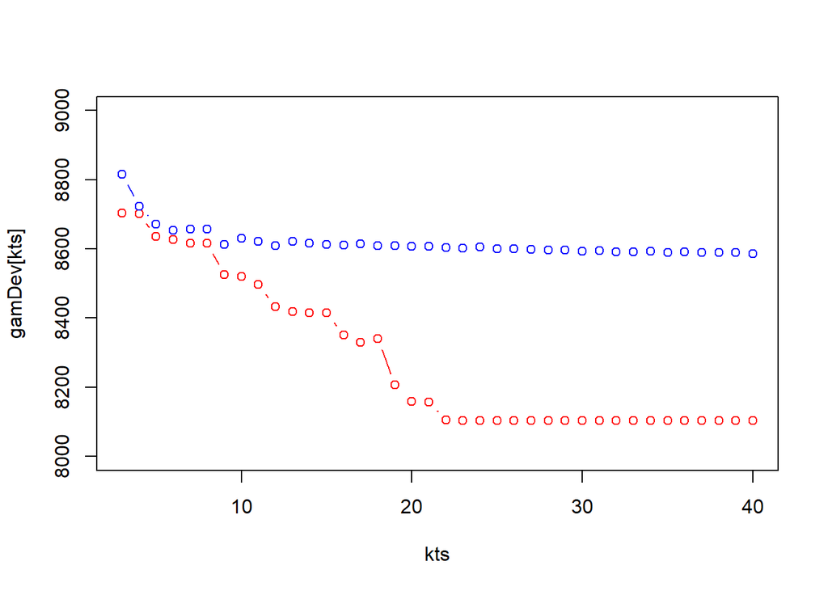

```r
kts     <- seq(3,40)
plot(kts,gamDev[kts],type="b",col="red",ylim=c(8000,9000))
points(kts,cgamDev[kts],type="b",col="blue")
```

The deviance from `cgam()` is more stable than it from `gam()`.

# Shape constrained additive models (SCAM)

Similar to `cgam`, `scam` is a shape constrained additive model (SCAM). It is a generalized linear model (GLM) in which the linear predictor is given by strictly parametric components plus a sum of smooth functions of the covariates where some of the functions are assumed to be shape constrained (Pya and Wood 2015, @pya2010additive).

```r
fitscam1 <- scam(yield ~ s(Wavail,k=4, bs="cv"),  data=datOR)
fitscam2 <- scam(yield ~ s(Wavail,k=10, bs="cv"), data=datOR)
fitscam3 <- scam(yield ~ s(Wavail,k=50, bs="cv"), data=datOR)
fitscam4 <- scam(yield ~ s(Wavail,k=100, bs="cv"),data=datOR)
```

A `SCAM` formula. This is exactly like the formula for a `GAM` except that monotone smooth terms. `bs="cv"` indicates concave P-splines.

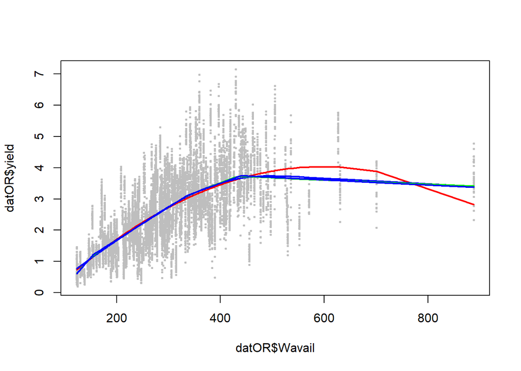

```r
plot(datOR$Wavail,datOR$yield,cex=0.5,pch=20,col="grey")
points(datOR$Wavail,fitscam1$fitted.values,type = "l",lwd=2,col="red")
points(datOR$Wavail,fitscam2$fitted.values,type = "l",lwd=2,col="blue")
points(datOR$Wavail,fitscam3$fitted.values,type = "l",lwd=2,col="green")
points(datOR$Wavail,fitscam4$fitted.values,type = "l",lwd=2,col="blue")
```

```r
fitscam1$aic;fitscam2$aic;fitscam3$aic;fitscam4$aic
```

```
## [1] 30828.17
```

```
## [1] 30670.38
```

```
## [1] 30596.57
```

```
## [1] 30590.81
```

```r
# BIC(fitscam1,fitscam2,fitscam3,fitscam4)
```

If we compare `cgam` and `scam` on the same amount of knots:

```r
fitcgam2 <- cgam(yield ~ s.incr.conc(Wavail,numknots=10), data=datOR)
fitscam2 <- scam(yield ~ s(Wavail,k=10, bs="cv"), data=datOR)
```

```r
fitcgam2$deviance;fitscam2$deviance
```

```
## [1] 8630.178
```

```
## [1] 8627.923
```

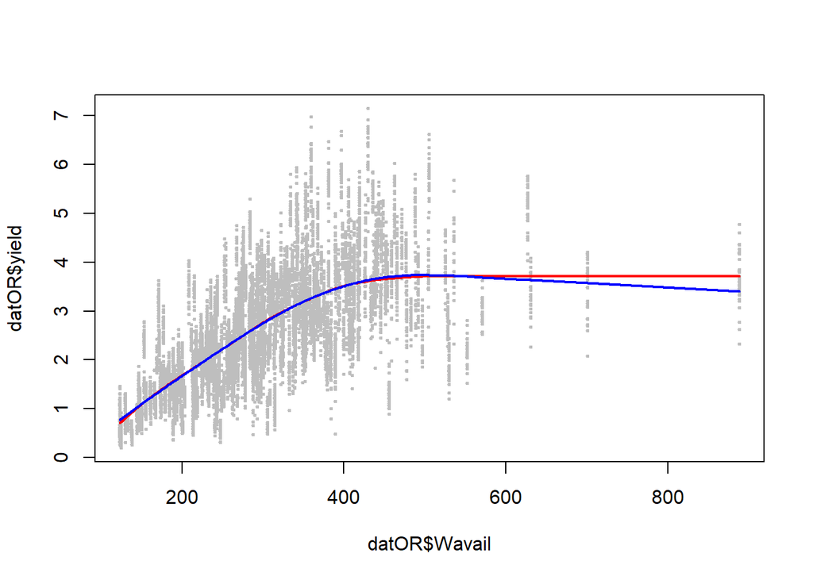

```r
plot(datOR$Wavail,datOR$yield,cex=0.5,pch=20,col="grey")
points(datOR$Wavail,fitcgam2$muhat,type = "l",lwd=2,col="red")
points(datOR$Wavail,fitscam2$fitted.values,type = "l",lwd=2,col="blue")
```

Here we propose a research topic: **Comparison of `gam`,`cgam`,`scam` (and `asreml`) on the performance of fitting longitudinal data set (repeatedly measured data set)**